# Generalized Assignment Problem

## About

This page contains an automatic benchmark between the C++ library idol and the Julia package Coluna.jl to test their implementation of the [Branch-and-Price algorithm](https://en.wikipedia.org/wiki/Branch_and_price) for solving instances of the [Generalized Assignment Problem](https://en.wikipedia.org/wiki/Generalized_assignment_problem).

The results presented here are automatically generated using GitHub Actions and R with Rmarkdown. Note that the experiments themselves are run with GitHub Actions for which the code is fully public and can be found [here for implementation details](https://github.com/hlefebvr/idol_benchmark) and [here for GitHub Actions configuration](https://github.com/hlefebvr/idol_benchmark/blob/main/.github/workflows/benchmark.yml).

The experiments were conducted on a free GitHub-hosted runner with an `ubuntu-latest` virtual machine with two CPU cores (x86_64), 7 GB of RAM and 14 GB of SSD space (see [hardware specifications here](https://docs.github.com/en/actions/using-github-hosted-runners/about-github-hosted-runners)).

Last automatic run: 18/01/25 02:51:43.

## Mathematical models

### Direct model

Let $m$ be the number of agents and let $n$ be the number of tasks to be performed.

Let $c_{ij}$ be the cost of assigning task $j$ to agent $i$, $w_{ij}$ be the resource consumption of task $j$ when performed by agent $i$ and let $t_i$ be the resource capacity of agent $i$.

The Generalized Assignment Problem (GAP) can be modeled as

$$\begin{array}{lll}
\min \ & \displaystyle \sum_{i=1}^m \sum_{j=1}^n c_{ij} x_{ij}
\\
\textrm{s.t.} \ & \displaystyle \sum_{j=1}^n w_{ij}x_{ij} \le
t_{i} & i=1,...,m \\
& \displaystyle \sum_{i=1}^m x_{ij} = 1 & j = 1,...,n \\
& x_{ij} \in \{ 0,1 \}.
\end{array}$$
Here, variable $x_{ij}$ equals $1$ if, and only if, task $j$ is assigned to agent $i$.

### Dantzig-Wolfe reformulation

Let us enumerate the list of all feasible assignments, i.e., let $\{ \bar{\mathrm{x}}_{ij}^e \}_{e\in E} = \{ x\in\{ 0, 1 \}^{mn} | \sum_{j=1}^n w_{ij}x_{ij} \le t_i \quad i = 1,...,m \}$ where $E$ denotes a list for their indices. The [Dantzig-Wolfe reformulation](https://en.wikipedia.org/wiki/Dantzig%E2%80%93Wolfe_decomposition) of GAP reads

$$\begin{array}{lll}
\min \ & \displaystyle \sum_{e\in E} \alpha_e \left(
\sum_{i=1}^m\sum_{j=1}^n c_{ij}\bar{\mathrm{x}}_{ij}^e \right) \\
\textrm{s.t.} \ & \displaystyle \sum_{i=1}^m
\alpha_e\bar{\mathrm{x}}_{ij}^e = 1 & j=1,...,n \\
& \displaystyle \sum_{e\in E} \alpha_e = 1 \\
& \alpha_e \ge 0
\end{array}$$

Though this model contains an exponential number of variables (i.e., columns) it can still be solved efficiently using [Column Generation](https://en.wikipedia.org/wiki/Column_generation) and [Branch and price](https://en.wikipedia.org/wiki/Branch_and_price).

In such a case, the pricing problem is a [Knapsack Problem](https://en.wikipedia.org/wiki/Knapsack_problem).

## Reading instances

In this section, we start by reading the raw computational results stored in CSV files. Note that these CSV files is stored as an *artifact* on the [GitHub Actions of the hlefebvr/idol_benchmark repository](https://github.com/hlefebvr/idol_benchmark/actions) and can be downloaded without restrictions by clicking on the latest workflow execution named `new_workflow` under the section “Artifacts” (also note that artifacts have a life span of 90 days).

```r
time_limit = 5 * 60
```

### Results obtained with idol

We first start to read results obtained using idol, which can be found inside the `results_GAP_idol.csv` file (Note that this file can be obtained by running `cat results_GAP_idol__*.csv > results_GAP_idol.csv` after having extracted the `.zip` the artifact).

```r
idol = read.csv("../results_GAP_idol.csv", header = FALSE)
colnames(idol) = c("instance", "solver", "with_heuristics", "smoothing_factor", "farkas_pricing", "clean_up_threshold", "branching_on_master", "status", "reason", "objective_value", "time")
```

```r
idol[idol$solver == "external",]$with_heuristics = NA
idol[idol$solver == "external" | idol$solver == "idol_bab",]$smoothing_factor = NA
idol[idol$solver == "external" | idol$solver == "idol_bab",]$farkas_pricing = NA
idol[idol$solver == "external" | idol$solver == "idol_bab",]$clean_up_threshold = NA
idol[idol$solver == "external" | idol$solver == "idol_bab",]$branching_on_master = NA
```

Then, we concatenate the parameter values with the method’s name to obtain a unique identifier for each tested method. The unique identifier can be `external`, `idol_bab_h<A>` or `idol_bap_h<A>_s<B>_f<C>_c<D>_m<E>` where

- `<A>` is 1 if the algorithm uses primal heuristics, 0 otherwise ;
- `<B>` is the smoothing factor (when relevant) multiplied by 100 ;
- `<C>` is 1 if Farkas pricing was used, 0 if artificial variables were used ;
- `<D>` is the clean up threshold which was used (when the threshold is reached, up to 1/3 of the threshold columns are removed from the pool) ;
- `<E>` is 1 branching was applied to the master problem and 0 otherwise.

```r
idol$solver_with_params = paste0(idol$solver, "_h", idol$with_heuristics, "_s", idol$smoothing_factor * 100, "_f", idol$farkas_pricing, "_c", idol$clean_up, "_m", idol$branching_on_master)
idol[idol$solver == "external",]$solver_with_params = "external"
idol[idol$solver == "idol_bab",]$solver_with_params = paste0("idol_bab_h", idol[idol$solver == "idol_bab",]$with_heuristics)
```

```r
idol =  idol %>%
  mutate(status = trimws(status))

if (sum(idol$reason == "TimeLimit") > 0) {
  idol[idol$reason == "TimeLimit",]$time = time_limit
}

if (sum(idol$status == "Fail") > 0) {
  idol[idol$status == "Fail",]$time = time_limit
}
```

### Results obtained with Coluna.jl

The results obtained using Coluna.jl can be found inside `results_GAP_coluna.csv`.

```r
coluna =  read.csv("../results_GAP_coluna.csv", header = FALSE)
colnames(coluna) = c("instance", "solver", "with_heuristics", "smoothing_factor", "farkas_pricing", "clean_up_threshold", "branching_on_master", "status", "objective_value", "time")
coluna$solver_with_params = "Coluna.jl"
coluna$reason = NA

if (sum(coluna$status == "ERROR") > 0) {
  coluna[coluna$status == "ERROR",]$time = time_limit
}

if (sum(coluna$status == "TIME_LIMIT") > 0) {
  coluna[coluna$status == "TIME_LIMIT",]$time = time_limit
}

if (sum(coluna$status == "INFEASIBLE") > 0) {
  coluna[coluna$status == "INFEASIBLE",]$objective_value = 1e+20
}
```

### All

We can now combine and print out the obtained computational results for each instance for each solver.

```r
results = rbind(idol, coluna)

results = results %>%
  mutate(
    n_agents = as.integer(sub('.*instance_n(\\d+)_\\d+__\\d+\\.txt', '\\1', instance)),
    n_jobs = as.integer(sub('.*instance_n\\d+_(\\d+)__\\d+\\.txt', '\\1', instance))
  )

results$unsolved = results$time >= time_limit | results$status == "ERROR" | results$status == "Fail"

if (sum(results$time > time_limit) > 0) {
  results[results$time > time_limit,]$time = time_limit
}
```

| instance | solver | with_heuristics | smoothing_factor | farkas_pricing | clean_up_threshold | branching_on_master | status | reason | objective_value | time | solver_with_params | n_agents | n_jobs | unsolved |
| --- | --- | --- | --- | --- | --- | --- | --- | --- | --- | --- | --- | --- | --- | --- |
| ./GAP/data/n2/instance_n2_30__0.txt | idol_bap | 1 | 0.0 | 0 | 1500 | 1 | Infeasible | TimeLimit | 1.000e+20 | 300.000000 | idol_bap_h1_s0_f0_c1500_m1 | 2 | 30 | TRUE |
| ./GAP/data/n2/instance_n2_30__1.txt | idol_bap | 1 | 0.0 | 0 | 1500 | 1 | Infeasible | - | 1.000e+20 | 0.515646 | idol_bap_h1_s0_f0_c1500_m1 | 2 | 30 | FALSE |
| ./GAP/data/n2/instance_n2_30__10.txt | idol_bap | 1 | 0.0 | 0 | 1500 | 1 | Optimal | Proved | 7.070e+02 | 0.890062 | idol_bap_h1_s0_f0_c1500_m1 | 2 | 30 | FALSE |
| ./GAP/data/n2/instance_n2_30__11.txt | idol_bap | 1 | 0.0 | 0 | 1500 | 1 | Optimal | Proved | 8.480e+02 | 0.528534 | idol_bap_h1_s0_f0_c1500_m1 | 2 | 30 | FALSE |
| ./GAP/data/n2/instance_n2_30__12.txt | idol_bap | 1 | 0.0 | 0 | 1500 | 1 | Infeasible | - | 1.000e+20 | 1.094810 | idol_bap_h1_s0_f0_c1500_m1 | 2 | 30 | FALSE |
| ./GAP/data/n2/instance_n2_30__13.txt | idol_bap | 1 | 0.0 | 0 | 1500 | 1 | Optimal | Proved | 8.060e+02 | 300.000000 | idol_bap_h1_s0_f0_c1500_m1 | 2 | 30 | TRUE |
| ./GAP/data/n2/instance_n2_30__14.txt | idol_bap | 1 | 0.0 | 0 | 1500 | 1 | Optimal | Proved | 8.040e+02 | 0.661390 | idol_bap_h1_s0_f0_c1500_m1 | 2 | 30 | FALSE |
| ./GAP/data/n2/instance_n2_30__15.txt | idol_bap | 1 | 0.0 | 0 | 1500 | 1 | Optimal | Proved | 7.970e+02 | 5.566090 | idol_bap_h1_s0_f0_c1500_m1 | 2 | 30 | FALSE |
| ./GAP/data/n2/instance_n2_30__16.txt | idol_bap | 1 | 0.0 | 0 | 1500 | 1 | Optimal | Proved | 8.280e+02 | 1.831410 | idol_bap_h1_s0_f0_c1500_m1 | 2 | 30 | FALSE |
| ./GAP/data/n2/instance_n2_30__17.txt | idol_bap | 1 | 0.0 | 0 | 1500 | 1 | Optimal | Proved | 8.790e+02 | 1.312390 | idol_bap_h1_s0_f0_c1500_m1 | 2 | 30 | FALSE |

[output cut: 950 more lines]

The list of all tested configuration of solvers can be obtained as follows.

```r
solvers = as.data.frame(unique(results$solver_with_params))
solvers = as.data.frame(sort(solvers[,1], decreasing = TRUE))
colnames(solvers) = "Solver"
```

| Solver |
| --- |
| idol_bap_h1_s30_f1_c1500_m1 |
| idol_bap_h1_s0_f1_c1500_m1 |
| idol_bap_h1_s0_f0_c1500_m1 |
| idol_bap_h1_s0_f0_c1500_m0 |
| idol_bab_h1 |
| idol_bab_h0 |
| external |
| Coluna.jl |

## Checking results

```r
compare_results = function (dataset, solver_a, solver_b) {

  results_a = dataset[dataset$solver_with_params == solver_a & dataset$time < time_limit & !(dataset$status %in% c("ERROR", "Fail")),]
  results_b = dataset[dataset$solver_with_params == solver_b & dataset$time < time_limit & !(dataset$status %in% c("ERROR", "Fail")),]

  merged = merge(results_a, results_b, by = c("instance"))

  return ( merged[ abs(merged$objective_value.x - merged$objective_value.y) > 1e-2 ,] )
}
```

Then, we compare all solvers together.

```r
mismatches = data.frame()

for (solver_with_params in unique(results$solver_with_params)) {
  mismatch = compare_results(results, "external", solver_with_params)
  if (nrow(mismatch) > 0) {
    print(paste0("There was mismatched instances between external solver and ", solver_with_params))
    mismatch = mismatch[,c("instance", "solver_with_params.x", "solver_with_params.y", "status.x", "status.y", "time.x", "time.y", "objective_value.x", "objective_value.y")]
    rownames(mismatch) = NULL
    mismatches = rbind(mismatches, mismatch)
  }
}

paged_table(mismatches)
```

## Some helper functions

### Performance profiles

To compare the different methods, we use performance profiles; see Dolan et al. (2002).

First, we associate colors to each solvers. Each solver will keep its color throughout the document.

```r
# Define color palette
colors <- scales::hue_pal()(length(unique(results$solver_with_params)))

# Define a mapping solver_with_params[i] -> color[i]
color_mapping = setNames(colors[1:length(solvers$Solver)], solvers$Solver)
```

Then, we introduce the function “add_performance_ratio” which augments a given data set with the performance of each solver with respect to the best solver.

```r
add_performance_ratio = function(dataset,
                                 criterion_column = "total_time",
                                 unsolved_column = "unsolved",
                                 instance_column = "instance",
                                 solver_column = "solver",
                                 output_column = "performance_ratio") {

  # Compute best score for each instance
  best = dataset %>%
    group_by(!!sym(instance_column)) %>%
    mutate(best_solver = min(!!sym(criterion_column)))

  # Compute performance ratio for each instance and solver
  result = best %>%
    group_by(!!sym(instance_column), !!sym(solver_column)) %>%
    mutate(!!sym(output_column) := !!sym(criterion_column) / best_solver) %>%
    ungroup()

  if (sum(result[,unsolved_column]) > 0) {
    result[result[,unsolved_column] == TRUE,output_column] = max(result[,output_column])
  }

  return (result)
}

plot_performance_profile = function(dataset,
                                    criterion_column,
                                    unsolved_column = "unsolved",
                                    instance_column = "instance",
                                    solver_column = "solver"
                                    ) {

  dataset_with_performance_ratios = add_performance_ratio(dataset,
                                                          criterion_column = criterion_column,
                                                          instance_column = instance_column,
                                                          solver_column = solver_column,
                                                          unsolved_column = unsolved_column)

  solved_dataset_with_performance_ratios = dataset_with_performance_ratios[!dataset_with_performance_ratios[,unsolved_column],]

  compute_performance_profile_point = function(method, data) {

    performance_ratios = solved_dataset_with_performance_ratios[solved_dataset_with_performance_ratios[,solver_column] == method,]$performance_ratio

    unscaled_performance_profile_point = ecdf(performance_ratios)(data)

    n_instances = sum(dataset[,solver_column] == method)
    n_solved_instances = sum(dataset[,solver_column] == method & !dataset[,unsolved_column])

    return( unscaled_performance_profile_point * n_solved_instances / n_instances )
  }

  perf = solved_dataset_with_performance_ratios %>%
    group_by(!!sym(solver_column)) %>%
    mutate(performance_profile_point = compute_performance_profile_point(unique(!!sym(solver_column)), performance_ratio))

  result = ggplot(data = perf, aes(x = performance_ratio, y = performance_profile_point, color = !!sym(solver_column))) +
              geom_line()

  return (result)
}
```

Here is an example.

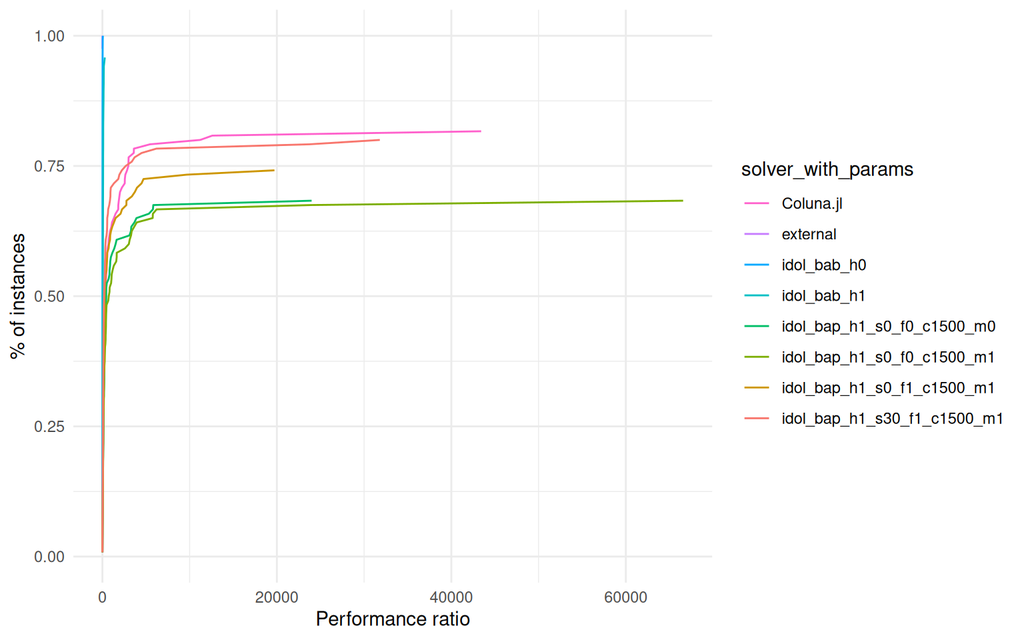

```r
plot_performance_profile(results,
                         criterion_column = "time",
                         solver_column = "solver_with_params") +
  labs(x = "Performance ratio", y = "% of instances") +
  scale_color_manual(values = color_mapping) +
  scale_y_continuous(limits = c(0, 1)) +
  theme_minimal()
```

As a complement, here is the ECDF of computation time.

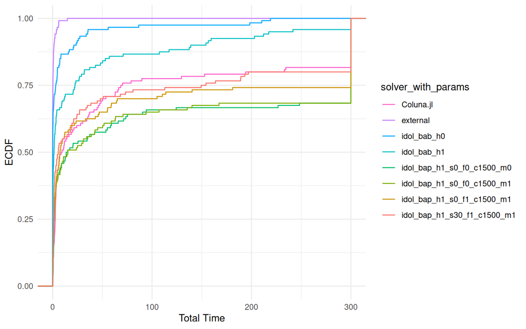

```r
ggplot(data = results, aes(x = time, color = solver_with_params)) +
  stat_ecdf(geom = "step") +
  labs(x = "Total Time", y = "ECDF") +
  scale_color_manual(values = color_mapping) +
  theme_minimal()
```

### Summary tables

We also introduce function `make_table` which builds a summary table from a given dataset where each column is defined as:

- `solver_with_params` the given name of the method ;
- `n_agents` the number of agents of the considered instances ;
- `n_jobs` the number of jobs of the considered instances ;
- `count` the total number of instances which were tried ;
- `unsolved` the number of instances which could not be solved within the given time limit (i.e., within 300 seconds) ;
- `time` the average computation time (over the solved instances only).

```r
make_table = function (dataset) {

  group_by = c("solver_with_params", "n_agents", "n_jobs")

  rownames(dataset) = NULL

  count = aggregate(dataset$instance, by = dataset[,group_by], FUN = length)
  colnames(count) = c(group_by, "count")

  unsolved = aggregate(dataset$time >= time_limit & !(dataset$status %in% c("ERROR", "Fail")), by = dataset[,group_by], FUN = sum)
  colnames(unsolved) = c(group_by, "unsolved")

  errors = aggregate(dataset$status %in% c("ERROR", "Fail"), by = dataset[,group_by], FUN = sum)
  colnames(errors) = c(group_by, "error")

  solved_filter = dataset$time < time_limit
  times = aggregate(dataset[solved_filter,]$time, by = dataset[solved_filter,group_by], FUN = mean)
  colnames(times) = c(group_by, "time")

  Table = merge(count, unsolved, by = group_by)
  Table = merge(Table, errors, by = group_by)
  Table = merge(Table, times, by = group_by)

  return (Table)
}
```

For example, the following table gathers results from the external solver.

```r
Table = make_table(results[results$solver == "external",])
```

| solver_with_params | n_agents | n_jobs | count | unsolved | error | time |
| --- | --- | --- | --- | --- | --- | --- |
| external | 2 | 30 | 20 | 0 | 0 | 0.0020714 |
| external | 2 | 40 | 20 | 0 | 0 | 0.0047648 |
| external | 3 | 30 | 20 | 0 | 0 | 0.0196303 |
| external | 3 | 40 | 20 | 0 | 0 | 0.0501532 |
| external | 4 | 60 | 20 | 0 | 0 | 1.4654285 |
| external | 4 | 80 | 20 | 0 | 0 | 2.0437742 |

## Computational results

### Branch-and-bound algorithm with idol

In this section, we evaluate the computational benefits obtained by idol’s primal heuristics.

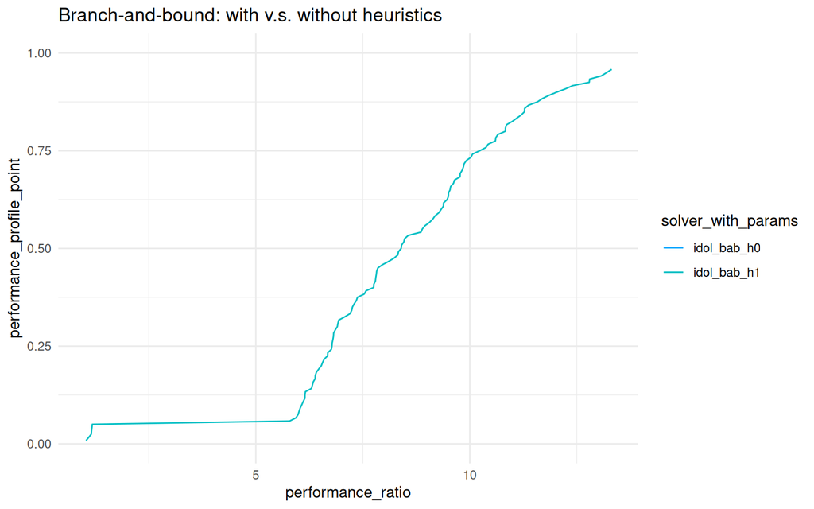

```r
plot_performance_profile(
  results[results$solver == "idol_bab",],
  criterion_column = "time",
  solver_column = "solver_with_params"
) +
  scale_color_manual(values = color_mapping) +
  scale_y_continuous(limits = c(0, 1)) +
  labs(title = "Branch-and-bound: with v.s. without heuristics") +
  theme_minimal()
```

```r
TableBaB = make_table(results[results$solver == "idol_bab",])
```

| solver_with_params | n_agents | n_jobs | count | unsolved | error | time |
| --- | --- | --- | --- | --- | --- | --- |
| idol_bab_h0 | 2 | 30 | 20 | 0 | 0 | 0.0077506 |
| idol_bab_h0 | 2 | 40 | 20 | 0 | 0 | 0.0150138 |
| idol_bab_h0 | 3 | 30 | 20 | 0 | 0 | 0.1053735 |
| idol_bab_h0 | 3 | 40 | 20 | 0 | 0 | 0.5887156 |
| idol_bab_h0 | 4 | 60 | 20 | 0 | 0 | 28.2287484 |
| idol_bab_h0 | 4 | 80 | 20 | 0 | 0 | 29.0110215 |
| idol_bab_h1 | 2 | 30 | 20 | 0 | 0 | 0.0840344 |
| idol_bab_h1 | 2 | 40 | 20 | 0 | 0 | 0.1563816 |
| idol_bab_h1 | 3 | 30 | 20 | 0 | 0 | 0.8824342 |
| idol_bab_h1 | 3 | 40 | 20 | 0 | 0 | 4.5562720 |
| idol_bab_h1 | 4 | 60 | 20 | 2 | 0 | 51.6442559 |
| idol_bab_h1 | 4 | 80 | 20 | 3 | 0 | 92.8513941 |

### Branch-and-price

#### Comparing with Coluna.jl

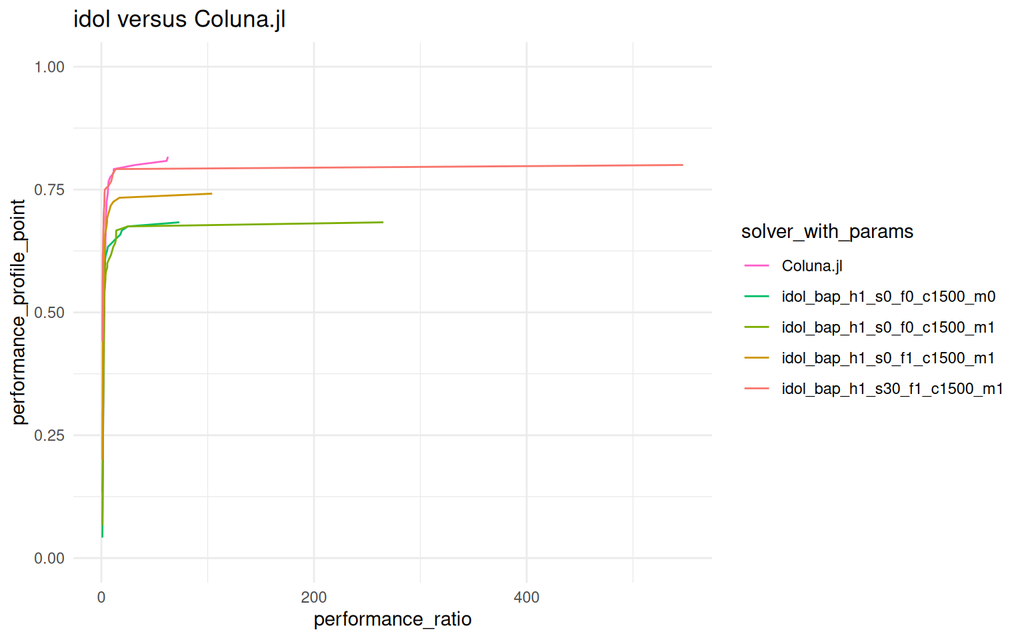

```r
to_save = plot_performance_profile(
  results[results$solver != "external" & results$solver != "idol_bab",],
  criterion_column = "time",
  solver_column = "solver_with_params"
) +
  scale_color_manual(values = color_mapping) +
  scale_y_continuous(limits = c(0, 1)) +
  labs(title = "idol versus Coluna.jl") +
  theme_minimal()
to_save
```

```r
ggsave("profile.png", plot = to_save, width = 8, height = 4)
```

```r
Table = make_table(
  results[results$solver_with_params != "external" & results$solver_with_params != "idol_bab_h0" & results$solver_with_params != "idol_bab_h1",]
)
```

| solver_with_params | n_agents | n_jobs | count | unsolved | error | time |
| --- | --- | --- | --- | --- | --- | --- |
| Coluna.jl | 2 | 30 | 20 | 1 | 0 | 3.3196842 |
| Coluna.jl | 2 | 40 | 20 | 5 | 0 | 6.9563333 |
| Coluna.jl | 3 | 30 | 20 | 0 | 0 | 5.0292500 |
| Coluna.jl | 3 | 40 | 20 | 1 | 0 | 19.1846316 |
| Coluna.jl | 4 | 60 | 20 | 3 | 0 | 57.8472941 |
| Coluna.jl | 4 | 80 | 20 | 12 | 0 | 96.8453750 |
| idol_bap_h1_s0_f0_c1500_m0 | 2 | 30 | 20 | 3 | 0 | 1.8185447 |
| idol_bap_h1_s0_f0_c1500_m0 | 2 | 40 | 20 | 11 | 0 | 5.5990329 |
| idol_bap_h1_s0_f0_c1500_m0 | 3 | 30 | 20 | 0 | 0 | 4.4839400 |
| idol_bap_h1_s0_f0_c1500_m0 | 3 | 40 | 20 | 1 | 0 | 26.1357658 |
| idol_bap_h1_s0_f0_c1500_m0 | 4 | 60 | 20 | 4 | 0 | 50.5681538 |
| idol_bap_h1_s0_f0_c1500_m0 | 4 | 80 | 20 | 19 | 0 | 248.3190000 |
| idol_bap_h1_s0_f0_c1500_m1 | 2 | 30 | 20 | 3 | 0 | 10.1277879 |
| idol_bap_h1_s0_f0_c1500_m1 | 2 | 40 | 20 | 8 | 0 | 14.4325669 |
| idol_bap_h1_s0_f0_c1500_m1 | 3 | 30 | 20 | 0 | 0 | 1.3981236 |
| idol_bap_h1_s0_f0_c1500_m1 | 3 | 40 | 20 | 2 | 0 | 27.7831824 |
| idol_bap_h1_s0_f0_c1500_m1 | 4 | 60 | 20 | 5 | 0 | 45.0061033 |
| idol_bap_h1_s0_f1_c1500_m1 | 2 | 30 | 20 | 3 | 0 | 1.7047291 |
| idol_bap_h1_s0_f1_c1500_m1 | 2 | 40 | 20 | 6 | 0 | 13.1864894 |
| idol_bap_h1_s0_f1_c1500_m1 | 3 | 30 | 20 | 0 | 0 | 0.8867882 |
| idol_bap_h1_s0_f1_c1500_m1 | 3 | 40 | 20 | 1 | 0 | 10.1070910 |
| idol_bap_h1_s0_f1_c1500_m1 | 4 | 60 | 20 | 4 | 0 | 51.1890287 |
| idol_bap_h1_s0_f1_c1500_m1 | 4 | 80 | 20 | 17 | 0 | 82.4818800 |
| idol_bap_h1_s30_f1_c1500_m1 | 2 | 30 | 20 | 2 | 0 | 10.0934189 |
| idol_bap_h1_s30_f1_c1500_m1 | 2 | 40 | 20 | 7 | 0 | 5.7133213 |
| idol_bap_h1_s30_f1_c1500_m1 | 3 | 30 | 20 | 0 | 0 | 0.6338529 |
| idol_bap_h1_s30_f1_c1500_m1 | 3 | 40 | 20 | 1 | 0 | 7.3684034 |
| idol_bap_h1_s30_f1_c1500_m1 | 4 | 60 | 20 | 2 | 0 | 43.7005989 |
| idol_bap_h1_s30_f1_c1500_m1 | 4 | 80 | 20 | 12 | 0 | 127.2514375 |

We also have a look at pathological instances for idol where the execution time is 20 % worst than Coluna.jl’s time. This is to spot and study why this happens and potentially fix the issue.

```r
find_pathological_instances = function (dataset, solver_a, solver_b) {

  results_a = dataset[dataset$solver_with_params == solver_a,]
  results_b = dataset[dataset$solver_with_params == solver_b,]

  merged = merge(results_a, results_b, by = c("instance"))

  result = merged[ merged$time.y > 1.2 * merged$time.x , c("instance", "time.x", "time.y", "status.x", "status.y")]

  colnames(result) = c("instance", paste0(solver_a, ".time"), paste0(solver_b, ".time"), paste0(solver_a, ".status"), paste0(solver_b, ".status"))

  rownames(result) = NULL

  return ( result )
}

pathological_instances = find_pathological_instances(results, "Coluna.jl", "idol_bap_h1_s0_f1_c1500_m1")
```

```r
knitr::kable(pathological_instances)
```

| instance | Coluna.jl.time | idol_bap_h1_s0_f1_c1500_m1.time | Coluna.jl.status | idol_bap_h1_s0_f1_c1500_m1.status |
| --- | --- | --- | --- | --- |
| ./GAP/data/n2/instance_n2_30__0.txt | 0.484 | 8.214500 | OPTIMAL | Optimal |
| ./GAP/data/n2/instance_n2_30__16.txt | 2.773 | 300.000000 | OPTIMAL | Optimal |
| ./GAP/data/n2/instance_n2_30__18.txt | 0.939 | 300.000000 | OPTIMAL | Infeasible |
| ./GAP/data/n2/instance_n2_30__7.txt | 0.273 | 300.000000 | OPTIMAL | Infeasible |
| ./GAP/data/n2/instance_n2_30__8.txt | 2.249 | 8.047500 | OPTIMAL | Optimal |
| ./GAP/data/n2/instance_n2_30__9.txt | 1.120 | 2.193860 | OPTIMAL | Optimal |
| ./GAP/data/n2/instance_n2_40__1.txt | 21.448 | 110.342000 | OPTIMAL | Optimal |
| ./GAP/data/n2/instance_n2_40__10.txt | 2.814 | 9.700290 | OPTIMAL | Optimal |
| ./GAP/data/n2/instance_n2_40__18.txt | 1.742 | 300.000000 | OPTIMAL | Infeasible |
| ./GAP/data/n2/instance_n2_40__3.txt | 13.320 | 300.000000 | OPTIMAL | Infeasible |
| ./GAP/data/n2/instance_n2_40__9.txt | 2.284 | 17.513100 | OPTIMAL | Optimal |
| ./GAP/data/n3/instance_n3_30__10.txt | 0.208 | 0.268833 | OPTIMAL | Optimal |
| ./GAP/data/n3/instance_n3_30__15.txt | 0.196 | 0.240100 | OPTIMAL | Optimal |
| ./GAP/data/n3/instance_n3_30__4.txt | 0.186 | 0.242703 | OPTIMAL | Optimal |
| ./GAP/data/n3/instance_n3_40__13.txt | 1.595 | 65.090100 | OPTIMAL | Optimal |
| ./GAP/data/n3/instance_n3_40__4.txt | 4.056 | 6.397880 | OPTIMAL | Optimal |
| ./GAP/data/n4/instance_n4_60__0.txt | 62.968 | 113.813000 | OPTIMAL | Optimal |
| ./GAP/data/n4/instance_n4_60__1.txt | 233.124 | 300.000000 | OPTIMAL | Feasible |
| ./GAP/data/n4/instance_n4_60__10.txt | 18.743 | 46.841300 | OPTIMAL | Optimal |
| ./GAP/data/n4/instance_n4_60__13.txt | 36.403 | 55.316100 | OPTIMAL | Optimal |
| ./GAP/data/n4/instance_n4_60__16.txt | 68.621 | 140.285000 | OPTIMAL | Optimal |
| ./GAP/data/n4/instance_n4_60__19.txt | 35.422 | 45.836000 | OPTIMAL | Optimal |
| ./GAP/data/n4/instance_n4_60__6.txt | 41.511 | 58.791700 | OPTIMAL | Optimal |
| ./GAP/data/n4/instance_n4_80__11.txt | 89.718 | 300.000000 | OPTIMAL | Infeasible |
| ./GAP/data/n4/instance_n4_80__12.txt | 194.142 | 300.000000 | OPTIMAL | Infeasible |
| ./GAP/data/n4/instance_n4_80__13.txt | 11.029 | 59.157400 | OPTIMAL | Optimal |
| ./GAP/data/n4/instance_n4_80__16.txt | 78.925 | 300.000000 | OPTIMAL | Infeasible |
| ./GAP/data/n4/instance_n4_80__18.txt | 66.425 | 300.000000 | OPTIMAL | Optimal |
| ./GAP/data/n4/instance_n4_80__3.txt | 234.519 | 300.000000 | OPTIMAL | Feasible |
| ./GAP/data/n4/instance_n4_80__8.txt | 34.387 | 300.000000 | OPTIMAL | Infeasible |

#### Comparing different settings of idol

##### All different settings of idol

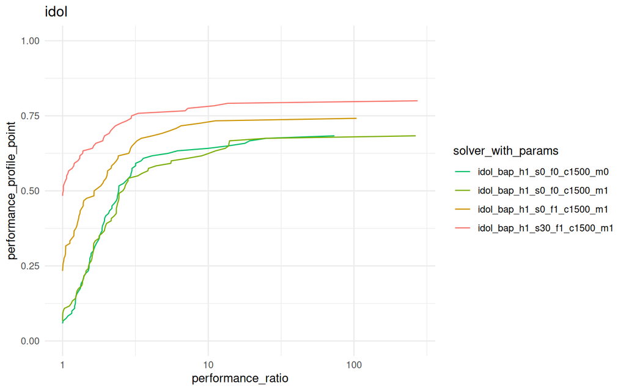

```r
plot_performance_profile(
  results[results$solver == "idol_bap",],
  criterion_column = "time",
  solver_column = "solver_with_params") +
  scale_color_manual(values = color_mapping) +
  scale_y_continuous(limits = c(0, 1)) +
  labs(title = "idol") +
  scale_x_log10() +
  theme_minimal()
```

##### Branching strategy: on master v.s. on pricing

Comparing branching scheme (on master or on pricing problem) without smoothing, using artificial variables (phase I) and primal heuristics.

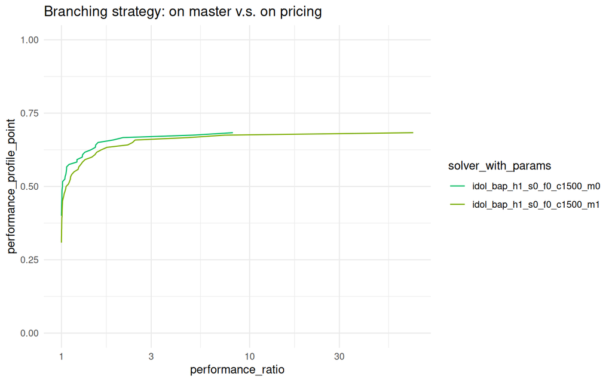

```r
plot_performance_profile(
  results[results$solver == "idol_bap" & results$with_heuristics == TRUE & results$smoothing_factor == 0 & results$farkas_pricing == 0,],
  criterion_column = "time",
  solver_column = "solver_with_params"
)  +
  scale_color_manual(values = color_mapping) +
  scale_y_continuous(limits = c(0, 1)) +
  labs(title = "Branching strategy: on master v.s. on pricing") +
  scale_x_log10() +
  theme_minimal()
```

##### Handling infeasibility: slack variables v.s. Farkas pricing

Comparing Farkas pricing with artificial variables (phase I) using primal heuristics, master branching and no smoothing.

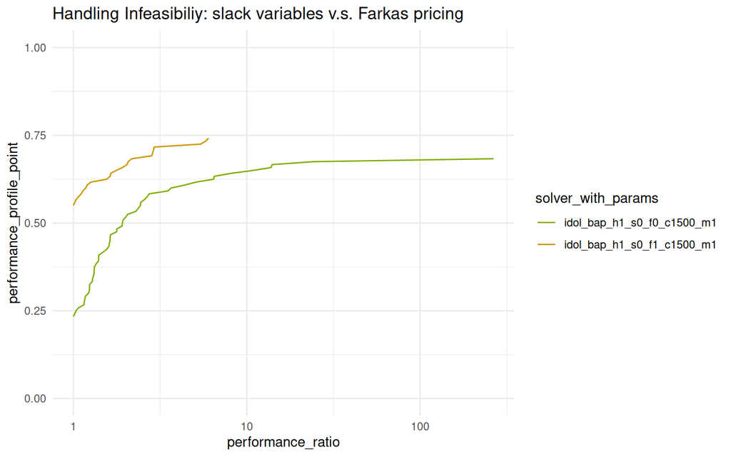

```r
plot_performance_profile(
  results[results$solver == "idol_bap" & results$with_heuristics == TRUE & results$smoothing_factor == 0 & results$branching_on_master == TRUE,],
  criterion_column = "time",
  solver_column = "solver_with_params"
)  +
  scale_color_manual(values = color_mapping) +
  scale_y_continuous(limits = c(0, 1)) +
  labs(title = "Handling Infeasibiliy: slack variables v.s. Farkas pricing") +
  scale_x_log10() +
  theme_minimal()
```

##### Stabilization by smoothing dual values

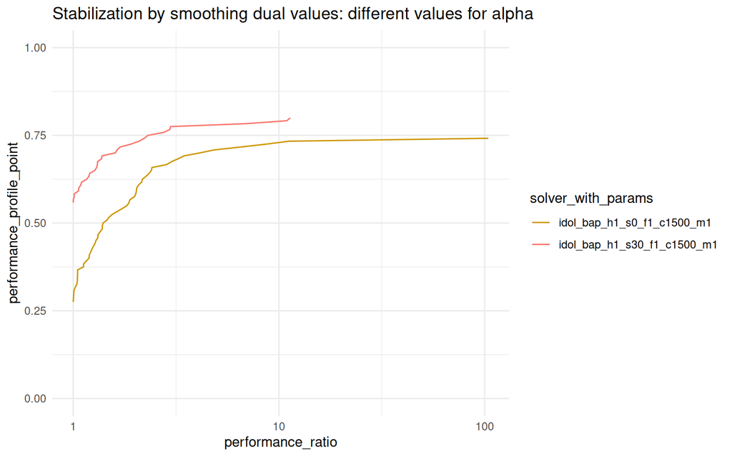

```r
plot_performance_profile(
  results[results$solver == "idol_bap" & results$with_heuristics == TRUE & results$branching_on_master == TRUE & results$farkas_pricing == TRUE,],
  criterion_column = "time",
  solver_column = "solver_with_params"
)  +
  scale_color_manual(values = color_mapping) +
  scale_y_continuous(limits = c(0, 1)) +
  labs(title = "Stabilization by smoothing dual values: different values for alpha") +
  scale_x_log10() +
  theme_minimal()
```

## Annex results for branch-and-price

### Reading the results

```r
annex = read.csv("../bap_annex_GAP_idol.csv", header = FALSE)
colnames(annex) = c("instance", "solver", "with_heuristics", "smoothing_factor", "farkas_pricing", "clean_up_threshold", "branching_on_master", "total_time", "bab_time", "cg_time", "master_time", "sp_time")
```

Then, we concatenate the parameter values with the method’s name to obtain a unique identifier for each tested method, just like before.

```r
annex$solver_with_params = paste0(annex$solver, "_h", annex$with_heuristics, "_s", annex$smoothing_factor * 100, "_f", annex$farkas_pricing, "_c", annex$clean_up, "_m", annex$branching_on_master)
```

### All

We can now combine and print out the obtained computational results for each instance for each solver.

```r
annex = annex %>%
  mutate(
    n_agents = as.integer(sub('.*instance_n(\\d+)_\\d+__\\d+\\.txt', '\\1', instance)),
    n_jobs = as.integer(sub('.*instance_n\\d+_(\\d+)__\\d+\\.txt', '\\1', instance))
  )


if (sum(annex$time > time_limit) > 0) {
  annex[annex$time > time_limit,]$time = time_limit
}

annex$overhead = annex$total_time - (annex$master_time + annex$sp_time)
```

| instance | solver | with_heuristics | smoothing_factor | farkas_pricing | clean_up_threshold | branching_on_master | total_time | bab_time | cg_time | master_time | sp_time | solver_with_params | n_agents | n_jobs | overhead |
| --- | --- | --- | --- | --- | --- | --- | --- | --- | --- | --- | --- | --- | --- | --- | --- |
| ./GAP/data/n4/instance_n4_60__0.txt | idol_bap | 1 | 0.3 | 1 | 1500 | 1 | 73.394400 | 73.394400 | 44.852000 | 0.711286 | 42.917700 | idol_bap_h1_s30_f1_c1500_m1 | 4 | 60 | 29.765414 |
| ./GAP/data/n4/instance_n4_60__1.txt | idol_bap | 1 | 0.3 | 1 | 1500 | 1 | 193.308000 | 193.308000 | 41.450100 | 6.037200 | 31.281400 | idol_bap_h1_s30_f1_c1500_m1 | 4 | 60 | 155.989400 |
| ./GAP/data/n4/instance_n4_60__10.txt | idol_bap | 1 | 0.3 | 1 | 1500 | 1 | 33.582500 | 33.582500 | 7.226160 | 0.966780 | 4.717790 | idol_bap_h1_s30_f1_c1500_m1 | 4 | 60 | 27.897930 |
| ./GAP/data/n4/instance_n4_60__11.txt | idol_bap | 1 | 0.3 | 1 | 1500 | 1 | 47.967600 | 47.967600 | 18.788800 | 2.126750 | 14.461300 | idol_bap_h1_s30_f1_c1500_m1 | 4 | 60 | 31.379550 |
| ./GAP/data/n4/instance_n4_60__12.txt | idol_bap | 1 | 0.3 | 1 | 1500 | 1 | 1.618930 | 1.618930 | 1.616520 | 0.223796 | 0.808929 | idol_bap_h1_s30_f1_c1500_m1 | 4 | 60 | 0.586205 |
| ./GAP/data/n4/instance_n4_60__13.txt | idol_bap | 1 | 0.3 | 1 | 1500 | 1 | 19.443900 | 19.443900 | 3.748660 | 0.577471 | 2.115840 | idol_bap_h1_s30_f1_c1500_m1 | 4 | 60 | 16.750589 |
| ./GAP/data/n4/instance_n4_60__14.txt | idol_bap | 1 | 0.3 | 1 | 1500 | 1 | 1.521550 | 1.521550 | 1.518790 | 0.230757 | 0.709547 | idol_bap_h1_s30_f1_c1500_m1 | 4 | 60 | 0.581246 |
| ./GAP/data/n4/instance_n4_60__15.txt | idol_bap | 1 | 0.3 | 1 | 1500 | 1 | 27.077900 | 27.077900 | 8.315900 | 0.462371 | 6.908590 | idol_bap_h1_s30_f1_c1500_m1 | 4 | 60 | 19.706939 |
| ./GAP/data/n4/instance_n4_60__16.txt | idol_bap | 1 | 0.3 | 1 | 1500 | 1 | 80.858100 | 80.858100 | 21.321400 | 2.688340 | 15.814700 | idol_bap_h1_s30_f1_c1500_m1 | 4 | 60 | 62.355060 |
| ./GAP/data/n4/instance_n4_60__17.txt | idol_bap | 1 | 0.3 | 1 | 1500 | 1 | 21.236000 | 21.236000 | 4.422250 | 0.622797 | 2.666490 | idol_bap_h1_s30_f1_c1500_m1 | 4 | 60 | 17.946713 |

[output cut: 470 more lines]

```r
id_vars = c(
  "instance", "solver", "with_heuristics", "smoothing_factor",
  "farkas_pricing", "clean_up_threshold", "branching_on_master",
  "solver_with_params", "n_agents", "n_jobs"
)

id_vals = c("total_time", "bab_time", "cg_time", "master_time", "sp_time", "overhead")

annex_long <- reshape(annex, varying = list(id_vals),
                      direction = "long", idvar = id_vars, timevar = "type", times = id_vals)

rownames(annex_long) = NULL
colnames(annex_long) = c(id_vars, "type", "value")

paged_table(annex_long)
```

| instance | solver | with_heuristics | smoothing_factor | farkas_pricing | clean_up_threshold | branching_on_master | solver_with_params | n_agents | n_jobs | type | value |
| --- | --- | --- | --- | --- | --- | --- | --- | --- | --- | --- | --- |
| ./GAP/data/n4/instance_n4_60__0.txt | idol_bap | 1 | 0.3 | 1 | 1500 | 1 | idol_bap_h1_s30_f1_c1500_m1 | 4 | 60 | total_time | 73.394400 |
| ./GAP/data/n4/instance_n4_60__1.txt | idol_bap | 1 | 0.3 | 1 | 1500 | 1 | idol_bap_h1_s30_f1_c1500_m1 | 4 | 60 | total_time | 193.308000 |
| ./GAP/data/n4/instance_n4_60__10.txt | idol_bap | 1 | 0.3 | 1 | 1500 | 1 | idol_bap_h1_s30_f1_c1500_m1 | 4 | 60 | total_time | 33.582500 |
| ./GAP/data/n4/instance_n4_60__11.txt | idol_bap | 1 | 0.3 | 1 | 1500 | 1 | idol_bap_h1_s30_f1_c1500_m1 | 4 | 60 | total_time | 47.967600 |
| ./GAP/data/n4/instance_n4_60__12.txt | idol_bap | 1 | 0.3 | 1 | 1500 | 1 | idol_bap_h1_s30_f1_c1500_m1 | 4 | 60 | total_time | 1.618930 |
| ./GAP/data/n4/instance_n4_60__13.txt | idol_bap | 1 | 0.3 | 1 | 1500 | 1 | idol_bap_h1_s30_f1_c1500_m1 | 4 | 60 | total_time | 19.443900 |
| ./GAP/data/n4/instance_n4_60__14.txt | idol_bap | 1 | 0.3 | 1 | 1500 | 1 | idol_bap_h1_s30_f1_c1500_m1 | 4 | 60 | total_time | 1.521550 |
| ./GAP/data/n4/instance_n4_60__15.txt | idol_bap | 1 | 0.3 | 1 | 1500 | 1 | idol_bap_h1_s30_f1_c1500_m1 | 4 | 60 | total_time | 27.077900 |
| ./GAP/data/n4/instance_n4_60__16.txt | idol_bap | 1 | 0.3 | 1 | 1500 | 1 | idol_bap_h1_s30_f1_c1500_m1 | 4 | 60 | total_time | 80.858100 |
| ./GAP/data/n4/instance_n4_60__17.txt | idol_bap | 1 | 0.3 | 1 | 1500 | 1 | idol_bap_h1_s30_f1_c1500_m1 | 4 | 60 | total_time | 21.236000 |

[output cut: 2870 more lines]

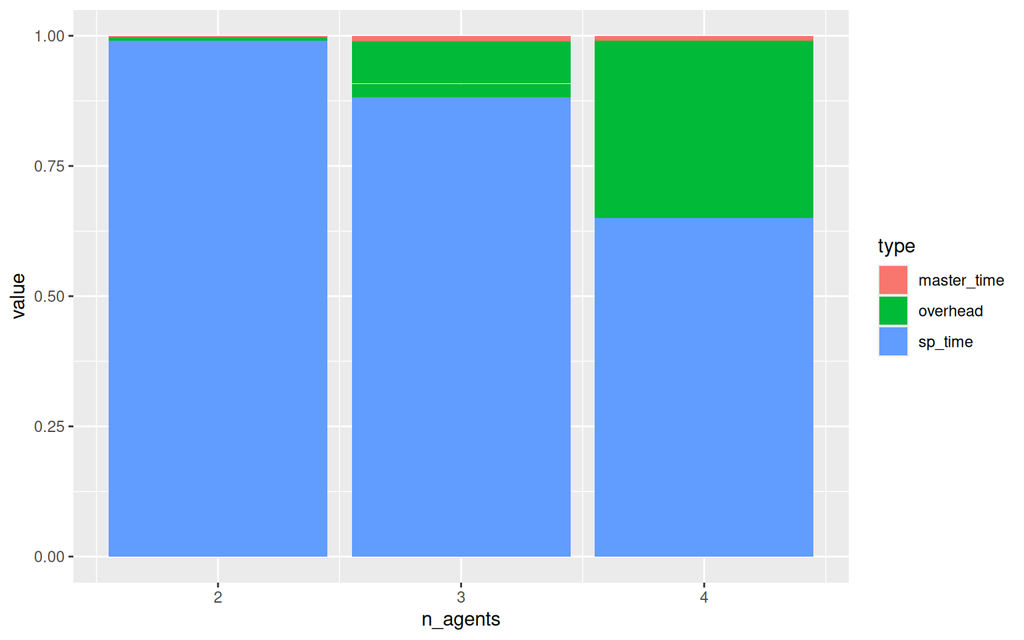

```r
ggplot(annex_long[annex_long$type %in% c("master_time", "sp_time", "overhead"),], aes(fill=type, y=value, x= n_agents)) +
    geom_bar(position="fill", stat="identity")
```